# Evaluation of the probability of causation approach for lung cancer: Scoping review

Count of included studies

Author

Affiliation

Javier Mancilla Galindo

Institute for Risk Assessment Sciences, Utrecht University, Utrecht, The Netherlands

Published

August 20, 2025

Keywords

probability of causation, assigned share, lung cancer, causality, scoping review

# Probability of Causation (PoC) ASReview screened and included records

The initial deduplicated dataset included n = 1127 records, out of which n = 184 were screened with ASReview, resulting in n = 133 irrelevant and n = 51 relevant records.

After full-text review, reclassification of studies resulted in n = 161 irrelevant and n = 23 relevant records. Therefore, a total of n = 28 irrelevant records were excluded due to the following reasons:

| poc | quantitative | lung_cancer | n |
| --- | --- | --- | --- |
| 0 | 0 | 1 | 6 |
| 0 | 1 | 1 | 1 |
| 1 | 0 | 0 | 4 |
| 1 | 0 | 1 | 14 |
| 1 | 1 | 0 | 3 |
| NA | NA | NA | 133 |

To summarize these reasons for exclusion, the following hierarchy was applied: poc > lung_cancer > quantitative.

- Not PoC, n = 7
- Not lung cancer, n = 7
- Not quantitative exposure-response, n = 14

# PoC snowball citation ASReview screened and included records

The updated dataset with the citations of the originally identified studies included n = 1714 records, out of which n = 42 were screened with ASReview, resulting in n = 34 irrelevant and n = 8 relevant records.

After full-text review, reclassification of studies resulted in n = 39 irrelevant and n = 3 relevant records. Therefore, a total of n = 5 irrelevant records were excluded due to the following reasons:

| poc | quantitative | lung_cancer | n |
| --- | --- | --- | --- |
| 1 | 0 | 0 | 2 |
| 1 | 1 | 0 | 3 |

- Not PoC, n = 0
- Not lung cancer, n = 5

# PRISMA diagram

The PRISMA2020 R package<sup>1</sup> was used to present the flow of studies in this review.

```r
source("scripts/PRISMA.R")
```

Since the produced diagram little flexibility to report screening of citations, the PRISMA_flowdiagram function was modified to allow for additional reporting.

```r
source("scripts/PRISMA_flowdiagram_modified.R")

source("scripts/PRISMA_enhanced.R")
```

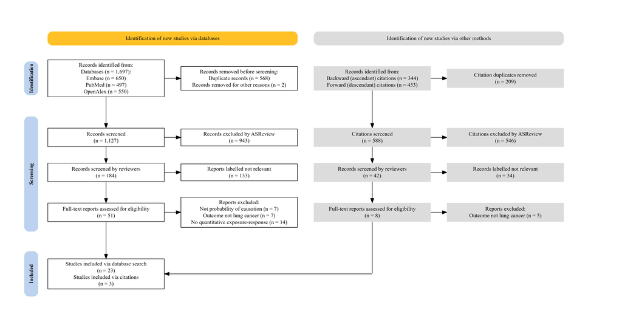

# References

1.

Haddaway NR, Page MJ, Pritchard CC, McGuinness LA. *PRISMA2020* : An R package and Shiny app for producing PRISMA 2020-compliant flow diagrams, with interactivity for optimised digital transparency and Open Synthesis. *Campbell Systematic Reviews*. 2022;18(2):e1230. doi:10.1002/cl2.1230

# Package References

- Aden-Buie G, Chang W, Schloerke B (2025). *chromote: Headless Chrome Web Browser Interface*. doi:10.32614/CRAN.package.chromote https://doi.org/10.32614/CRAN.package.chromote, R package version 0.5.1, https://CRAN.R-project.org/package=chromote.
- Chang W (2025). *webshot2: Take Screenshots of Web Pages*. doi:10.32614/CRAN.package.webshot2 https://doi.org/10.32614/CRAN.package.webshot2, R package version 0.1.2, https://CRAN.R-project.org/package=webshot2.
- Cheng J, Sievert C, Schloerke B, Chang W, Xie Y, Allen J (2024). *htmltools: Tools for HTML*. doi:10.32614/CRAN.package.htmltools https://doi.org/10.32614/CRAN.package.htmltools, R package version 0.5.8.1, https://CRAN.R-project.org/package=htmltools.
- Grolemund G, Wickham H (2011). “Dates and Times Made Easy with lubridate.” *Journal of Statistical Software*, *40*(3), 1-25. https://www.jstatsoft.org/v40/i03/.
- Haddaway NR, Page MJ, Pritchard CC, McGuinness LA (2022). “PRISMA2020: An R package and Shiny app for producing PRISMA 2020-compliant flow diagrams, with interactivity for optimised digital transparency and Open Synthesis.” *Campbell Systematic Reviews*, *18*(2), e1230. doi:10.1002/cl2.1230 https://doi.org/10.1002/cl2.1230.
- Iannone R, Cheng J, Schloerke B, Hughes E, Lauer A, Seo J, Brevoort K, Roy O (2025). *gt: Easily Create Presentation-Ready Display Tables*. doi:10.32614/CRAN.package.gt https://doi.org/10.32614/CRAN.package.gt, R package version 1.0.0, https://CRAN.R-project.org/package=gt.
- Makowski D, Lüdecke D, Patil I, Thériault R, Ben-Shachar M, Wiernik B (2023). “Automated Results Reporting as a Practical Tool to Improve Reproducibility and Methodological Best Practices Adoption.” *CRAN*. https://easystats.github.io/report/.
- Müller K, Wickham H (2025). *tibble: Simple Data Frames*. doi:10.32614/CRAN.package.tibble https://doi.org/10.32614/CRAN.package.tibble, R package version 3.3.0, https://CRAN.R-project.org/package=tibble.
- R Core Team (2025). *R: A Language and Environment for Statistical Computing*. R Foundation for Statistical Computing, Vienna, Austria. https://www.R-project.org/.
- Rinker TW, Kurkiewicz D (2018). *pacman: Package Management for R*. version 0.5.0, http://github.com/trinker/pacman.
- Vaidyanathan R, Xie Y, Allaire J, Cheng J, Sievert C, Russell K (2023). *htmlwidgets: HTML Widgets for R*. doi:10.32614/CRAN.package.htmlwidgets https://doi.org/10.32614/CRAN.package.htmlwidgets, R package version 1.6.4, https://CRAN.R-project.org/package=htmlwidgets.
- Wickham H (2016). *ggplot2: Elegant Graphics for Data Analysis*. Springer-Verlag New York. ISBN 978-3-319-24277-4, https://ggplot2.tidyverse.org.
- Wickham H (2023). *forcats: Tools for Working with Categorical Variables (Factors)*. doi:10.32614/CRAN.package.forcats https://doi.org/10.32614/CRAN.package.forcats, R package version 1.0.0, https://CRAN.R-project.org/package=forcats.
- Wickham H (2023). *stringr: Simple, Consistent Wrappers for Common String Operations*. doi:10.32614/CRAN.package.stringr https://doi.org/10.32614/CRAN.package.stringr, R package version 1.5.1, https://CRAN.R-project.org/package=stringr.
- Wickham H, Averick M, Bryan J, Chang W, McGowan LD, François R, Grolemund G, Hayes A, Henry L, Hester J, Kuhn M, Pedersen TL, Miller E, Bache SM, Müller K, Ooms J, Robinson D, Seidel DP, Spinu V, Takahashi K, Vaughan D, Wilke C, Woo K, Yutani H (2019). “Welcome to the tidyverse.” *Journal of Open Source Software*, *4*(43), 1686. doi:10.21105/joss.01686 https://doi.org/10.21105/joss.01686.
- Wickham H, Bryan J (2025). *readxl: Read Excel Files*. doi:10.32614/CRAN.package.readxl https://doi.org/10.32614/CRAN.package.readxl, R package version 1.4.5, https://CRAN.R-project.org/package=readxl.
- Wickham H, François R, Henry L, Müller K, Vaughan D (2023). *dplyr: A Grammar of Data Manipulation*. doi:10.32614/CRAN.package.dplyr https://doi.org/10.32614/CRAN.package.dplyr, R package version 1.1.4, https://CRAN.R-project.org/package=dplyr.
- Wickham H, Henry L (2025). *purrr: Functional Programming Tools*. doi:10.32614/CRAN.package.purrr https://doi.org/10.32614/CRAN.package.purrr, R package version 1.1.0, https://CRAN.R-project.org/package=purrr.
- Wickham H, Hester J, Bryan J (2024). *readr: Read Rectangular Text Data*. doi:10.32614/CRAN.package.readr https://doi.org/10.32614/CRAN.package.readr, R package version 2.1.5, https://CRAN.R-project.org/package=readr.
- Wickham H, Vaughan D, Girlich M (2024). *tidyr: Tidy Messy Data*. doi:10.32614/CRAN.package.tidyr https://doi.org/10.32614/CRAN.package.tidyr, R package version 1.3.1, https://CRAN.R-project.org/package=tidyr.
- Xie Y, Lesur R, Thorne B, Tan X (2025). *pagedown: Paginate the HTML Output of R Markdown with CSS for Print*. doi:10.32614/CRAN.package.pagedown https://doi.org/10.32614/CRAN.package.pagedown, R package version 0.22, https://CRAN.R-project.org/package=pagedown.

> For specific information on the operating system, R version, and R package versions used, please refer to the R/session folder in the GitHub repository.